# Annual Peaks in Selected SW Michigan Streamgages

Dave Holtschlag

March 2, 2018

## Read Selected PeakFQ Statistics

Four PeakFQ analyses were conducted: (1) Data through 2017 by B17B methods and weighted skew, (2) Data through 2017 by EMA methods and station skew, (3) through 2018 by B17B methods and weighted skew, (2) Data through 2018 by EMA methods and station skew. The regional skew used for the B17B methods was 0.081, with a mean square error of 0.20 (rmse 0.4472136). No regional skew value was available on the date of the analysis to use weighted skew with EMA methods. All analyses used the multiple Grubbs-Beck test for low-outliers.

The output from each of the four PeakFQ analysis was processed with python program read_data2.py to extract selected statistics for this analysis. In this process, the PRT files for the 2018 analyses were modifed slightly by appended as ‘0’ to the variance estimate for the 0.0020 AEP flood to distinguish so the variance estimate reads ‘0.00200’ rather than ‘0.002’. This distinguished the variance estimate from the AEP used to key the read statement.

```r
# Read output based on data through 2017 using B17B and weighted skew
df2017_B17B <- read_tsv('data/WeaverSet_2017_B17B_WGT_MGB.out')
# Read output based on data through 2017 using EMA  and stations skew
df2017_EMA  <- read_tsv('data/WeaverSet_2017_EMA_STA_MGB.out')
# Read output based on data through 2018 using B17B and weighted skew
df2018_B17B <- read_tsv('data/WeaverSet_2018_B17B_WGT_MGB.out')
# Read output based on data through 2018 using EMA  and stations skew
df2018_EMA  <- read_tsv('data/WeaverSet_2018_EMA_STA_MGB.out')
# Streamgages with Period of record peaks in 2018
por_2018 <- c('04096015', '04096405', '04096515', '04097500', '04097540',
              '04101500', '04102500', '04104945', '04106400', '04111000',
              '04116000')

# Initialize logical field for POR indicator
df2017_B17B$por_2018 <- FALSE
df2018_B17B$por_2018 <- FALSE
df2017_EMA$por_2018  <- FALSE
df2018_EMA$por_2018  <- FALSE

# Find indices of POR streamgages
ndx <- which(df2017_B17B$sta_no %in% por_2018)

# Flag streamgages with POR in 2018
df2017_B17B$por_2018[ndx] <- TRUE
df2018_B17B$por_2018[ndx] <- TRUE
df2017_EMA$por_2018[ndx]  <- TRUE
df2018_EMA$por_2018[ndx]  <- TRUE


df2018 <-
   left_join(df2018_B17B[, c('sta_no','sta_name', 'no_peaks','q_010_est', 'por_2018')],
             df2018_EMA[, c('sta_no','q_010_est')], suffix = c('B17B','EMA'),
             by = 'sta_no')

knitr::kable(df2018[,c('sta_no', 'sta_name', 'no_peaks', 'q_010_estB17B', 'q_010_estEMA', 'por_2018')],
                         caption = 'Selected streamgages in SW Michigan through 2018 based on B17B and EMA methods.')
```

Selected streamgages in SW Michigan through 2018 based on B17B and EMA methods.

| sta_no | sta_name | no_peaks | q_010_estB17B | q_010_estEMA | por_2018 |
| --- | --- | --- | --- | --- | --- |
| 04096015 | GALIEN RIVER NEAR SAWYER, MI | 23 | 3426.0 | 3857.0 | TRUE |
| 04096405 | ST. JOSEPH RIVER AT BURLINGTON, MI | 56 | 1514.0 | 1438.0 | TRUE |
| 04096515 | SOUTH BRANCH HOG CREEK NEAR ALLEN, MI | 49 | 854.5 | 841.2 | TRUE |
| 04097500 | ST. JOSEPH RIVER AT THREE RIVERS, MI | 59 | 8312.0 | NA | TRUE |
| 04097540 | PRAIRIE RIVER NEAR NOTTAWA, MI | 56 | 882.8 | 851.2 | TRUE |
| 04099000 | ST. JOSEPH RIVER AT MOTTVILLE, MI | 95 | 11110.0 | 11300.0 | FALSE |
| 04101500 | ST. JOSEPH RIVER AT NILES, MI | 88 | 22580.0 | 22330.0 | TRUE |
| 04102500 | PAW PAW RIVER AT RIVERSIDE, MI | 67 | 4232.0 | 4489.0 | TRUE |
| 04104945 | WANADOGA CREEK NEAR BATTLE CREEK, MI | 24 | 1220.0 | 1069.0 | TRUE |
| 04105000 | BATTLE CREEK AT BATTLE CREEK, MI | 87 | 3880.0 | NA | FALSE |
| 04105500 | KALAMAZOO RIVER NEAR BATTLE CREEK, MI | 81 | 6855.0 | 6907.0 | FALSE |
| 04106000 | KALAMAZOO RIVER AT COMSTOCK, MI | 81 | 7260.0 | 7207.0 | FALSE |
| 04106400 | WEST FORK PORTAGE CREEK AT KALAMAZOO, MI | 59 | 59.7 | 61.3 | TRUE |
| 04109000 | GRAND RIVER AT JACKSON, MI | 83 | 1072.0 | 1079.0 | FALSE |
| 04111000 | GRAND RIVER NEAR EATON RAPIDS, MI | 57 | 4728.0 | 4067.0 | TRUE |
| 04111379 | RED CEDAR RIVER NEAR WILLIAMSTON, MI | 31 | 2520.0 | 2692.0 | FALSE |
| 04112000 | SLOAN CREEK NEAR WILLIAMSTON, MI | 64 | 1030.0 | 1034.0 | FALSE |
| 04112500 | RED CEDAR RIVER AT EAST LANSING, MI | 110 | 6530.0 | 6555.0 | FALSE |
| 04113000 | GRAND RIVER AT LANSING, MI | 118 | 16710.0 | 16800.0 | FALSE |
| 04116000 | GRAND RIVER AT IONIA, MI | 70 | 27800.0 | 24850.0 | TRUE |
| 04117500 | THORNAPPLE RIVER NEAR HASTINGS, MI | 74 | 6676.0 | 6594.0 | FALSE |
| 04119000 | GRAND RIVER AT GRAND RAPIDS, MI | 118 | 48880.0 | 47680.0 | FALSE |

## Relations among 0.01 AEP estimates using B17B methods for 2017 and 2018

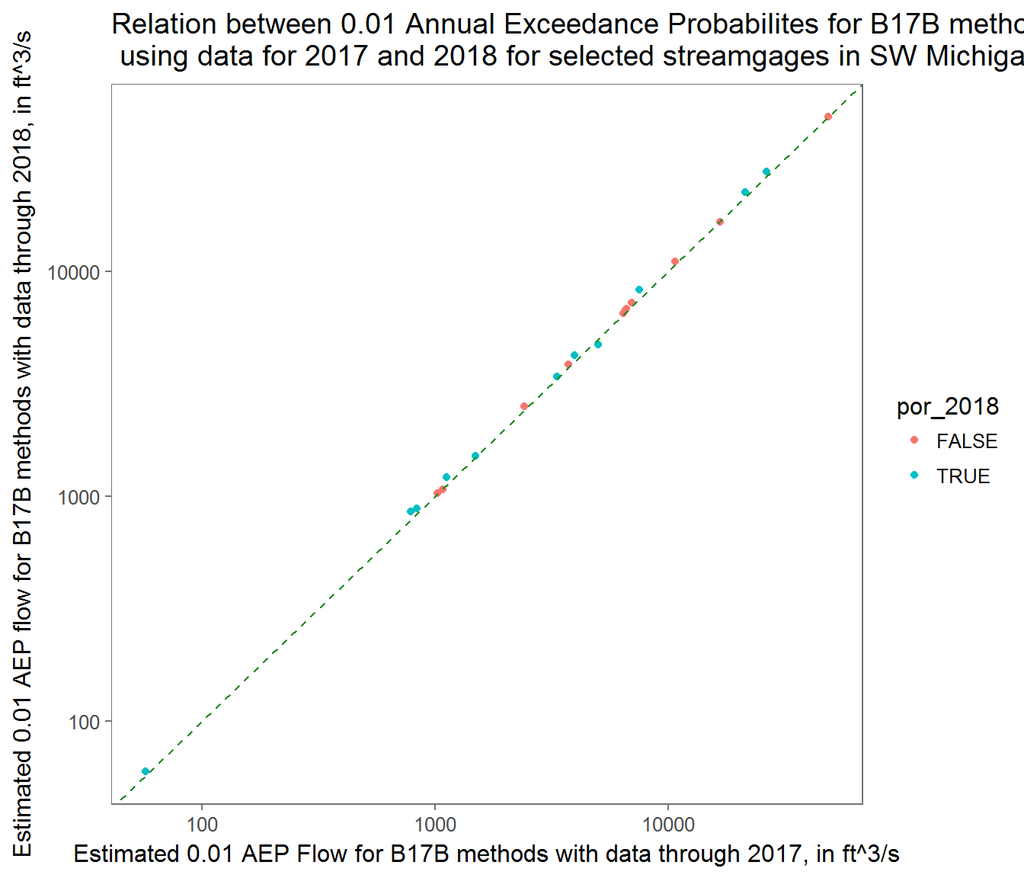

```r
# merge data for B17B methods for years through 2017 and 2018
df_B17B_17_18 <-
   left_join(df2017_B17B[,c('sta_no', 'q_010_est', 'por_2018')], df2018_B17B[, c('sta_no', 'q_010_est')],
             suffix = c('2017', '2018'), by = 'sta_no')

df_B17B_17_18 %>%
   ggplot( aes(x = q_010_est2017, y = q_010_est2018, color = por_2018)) +
   geom_point() +
   theme_few()  +
   scale_x_continuous( trans = 'log10') +
   scale_y_continuous( trans = 'log10') +
   labs( x = 'Estimated 0.01 AEP Flow for B17B methods with data through 2017, in ft^3/s',
         y = 'Estimated 0.01 AEP flow for B17B methods with data through 2018, in ft^3/s',
         title = paste('Relation between 0.01 Annual Exceedance Probabilites for B17B methods','\n',
                       'using data for 2017 and 2018 for selected streamgages in SW Michigan')) +
   geom_abline( intercept = 0, slope = 1, color = 'forestgreen', linetype = 'dashed')
```

## Relations among 0.01 AEP estimates using EMA methods for 2017 and 2018

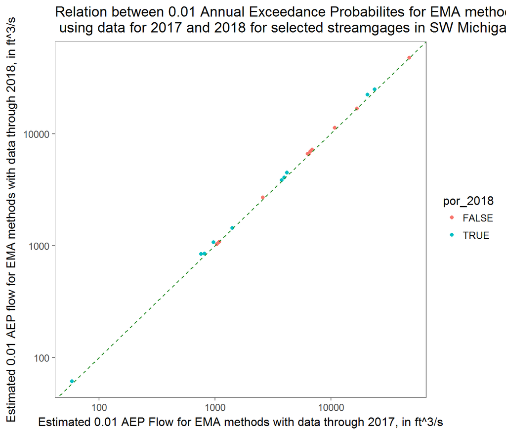

```r
# merge data for B17B methods for years through 2017 and 2018
df_EMA_17_18 <-
   left_join(df2017_EMA[,c('sta_no', 'q_010_est', 'por_2018')], df2018_EMA[, c('sta_no', 'q_010_est')],
             suffix = c('2017', '2018'), by = 'sta_no')

df_EMA_17_18 %>%
   ggplot( aes(x = q_010_est2017, y = q_010_est2018, color = por_2018)) +
   geom_point() +
   theme_few()  +
   scale_x_continuous( trans = 'log10') +
   scale_y_continuous( trans = 'log10') +
   labs( x = 'Estimated 0.01 AEP Flow for EMA methods with data through 2017, in ft^3/s',
         y = 'Estimated 0.01 AEP flow for EMA methods with data through 2018, in ft^3/s',
         title = paste('Relation between 0.01 Annual Exceedance Probabilites for EMA methods','\n',
                       'using data for 2017 and 2018 for selected streamgages in SW Michigan')) +
   geom_abline( intercept = 0, slope = 1, color = 'forestgreen', linetype = 'dashed')
```

## Relations among 0.01 AEP estimates using B17B and EMA methods for data through 2018

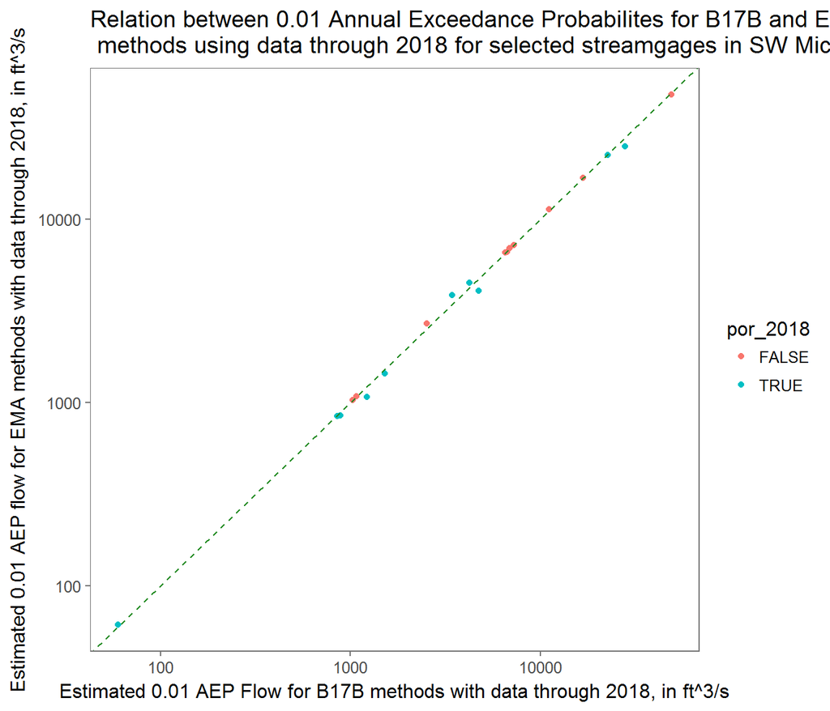

```r
# merge data for B17B and EMA methods for 2018
df_B17B_EMA_18 <-
   left_join(df2018_B17B[,c('sta_no', 'q_010_est', 'por_2018')], df2018_EMA[, c('sta_no', 'q_010_est')],
             suffix = c('B17B', 'EMA'), by = 'sta_no') %>%
   mutate(log_diff = log10(q_010_estB17B) - log10(q_010_estEMA))

df_B17B_EMA_18 %>%
   ggplot( aes(x = q_010_estB17B, y = q_010_estEMA, color = por_2018)) +
   geom_point() +
   theme_few()  +
   scale_x_continuous( trans = 'log10') +
   scale_y_continuous( trans = 'log10') +
   labs( x = 'Estimated 0.01 AEP Flow for B17B methods with data through 2018, in ft^3/s',
         y = 'Estimated 0.01 AEP flow for EMA methods with data through 2018, in ft^3/s',
         title = paste('Relation between 0.01 Annual Exceedance Probabilites for B17B and EMA','\n',
                       'methods using data through 2018 for selected streamgages in SW Michigan')) +
   geom_abline( intercept = 0, slope = 1, color = 'forestgreen', linetype = 'dashed')
```

```r
   # annotate(x = )
```